# Tutorial 01: introdução ao R

Prof. Fernando H. A. Farache

2020-04-11 (v. 2021-04-09)

**Objetivos**

O objetivo desta aula é oferecer os alunos uma introdução geral ao ambiente R, que será usado para as análises de dados na disciplina. Ao final dessa aula, os discentes estarão familiarizados com os seguintes temas:

- A Interface do RStudio
- Sintaxe e operações matemáticas
- Objetos
- Criando scripts
- Funções
- Pacotes
- Tipos de objetos
- Trabalhando com vetores
- Trabalhando com data frames

Os scrips utilizados abaixo são baseados nas referências Venables *et al.* (2020), Landeiro (2011), e na página http://material.curso-r.com/rbase/.

# 1 A Interface do RStudio

Você pode observar 4 janelas no RStudio.

- **Editor**: é onde digitamos os códigos. Nele temos um arquivo de texto que chamamos script.
- **Console**: é a linha de comandos do R. Os comandos executados aparecem depois do símbolo “>”, e os resultados também aparecem no console.
- **Ambiente e história**: onde ficam os objetos criados. “História”apresenta linhas de código recentemente utilizadas.
- **Output**: Apresenta outras informações, como gráficos gerados, arquivos de ajuda, etc.

[figure not shown]

Fonte: http://material.curso-r.com/rbase/

# 2 Sintaxe e operações aritméticas

O R pode ser utilizado para realizar cálculos simples. Para executar um comando no R, faça alguma das duas ações:

- Digite 1 + 2 no **editor** e pressione **Ctrl+Enter**. Assim a informação passada no editor será executada no script
- Digite 1 + 2 diretamente no **console** e pressione ENTER

```r
1 + 2
```

```
## [1] 3
```

Na sintaxe exibida acima, temos que o valor digitado aparece no quadrado mais escuro e a resposta observada no R aparece no quadrado mais claro, após os dois hashtags. A operação acima no console do R aparecerá como abaixo:

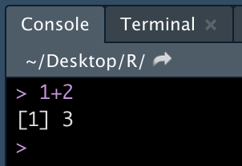

Como resposta, teremos o resultado da operação.

**Exemplos de operações aritméticas no R**

```r
10 + 5 #soma
10 - 5 #subtração
10 * 5 #multipicação
10 / 5 #divisão
11 %/% 5 #divisão de inteiros
11 %% 5 #divisão modular
```

# 3 Atribuição; criando objetos

Ao executar o comando executado acima, obtemos o resultado da operação. No entanto esse resultado não é salvo em nenhum local. Na linguagem R, para que nosso resultado fique salvo para uma próxima etapa, devemos criar um **objeto**.

O R é uma linguagem orientada a objetos. As planilhas, resultados de análise, funções utilizadas para realizar as análises, etc, são salvos como objetos.

Para criar objetos, utilizamos o sinal de **atribuir (<-)**. essa formula permite que criemos um objeto com o resultado da nossa operação.

```r
a <- 1 + 2
```

Observe que, diferentemente do passo anterior, não obtivemos um resultado no prompt. Entretanto podemos observar o resultado chamando pelo objeto *a* que criamos. Para isso, simplesmente escrevemos o nome do objeto (*a*) no script e clicamos **CTRL+ENTER**:

```r
a
```

```
## [1] 3
```

Podemos utilizar os símbolos de atribuição como o sinal de menor seguido de hífen, formando uma seta (<-), mas isto em geral também pode ser feito utilizando o sinal de igualdade (=). Após digitar o valor, você poderá utilizar o símbolo de atribuição ao contrário. A função **assign** pode ser utilizada para atribuição (obs - funções são explicadas em um tópico posterior):

```r
#todos os comandos abaixo funcionam da mesma forma: atribuem o valor de 1 + 2 ao objeto a
a <- 1 + 2
a = 1 + 2
1 + 2 -> a
assign("a", 1 + 2)
```

**Nomes de objetos** Podemos colocar o nome que quisermos em um objeto. No exemplo abaixo criamos um objeto de texto *Meu.objeto*. Para inserir texto, colocamos este entre aspas ("“). Observe que ao chamar o objeto, tivemos erro no primeiro caso. isso se deve ao fato de utilizarmos letra maiúscula no nome do objeto. Assim, vemos que o R é”case sensitive", ou seja, difere entre maiúsculas e minúsculas.

```r
Meu.objeto <- "Aprender R é fácil"
meu.objeto #retorna uma mensagem de erro, pois escrevemos o nome do objeto em minúsculo.
```

```
## Error in eval(expr, envir, enclos): object 'meu.objeto' not found
```

```r
Meu.objeto
```

```
## [1] "Aprender R é fácil"
```

**Obs.** Tudo que aparece depois do símbolo ‘#’ não é lido pelo R. Esse símbolo pode ser usado para colocar comentários no seu script.

Alguns nomes de objeto não são aceitos, por exemplo:

- O nome de um objeto não pode começar por um número;
- O nome de um objeto não pode ser separado por hífen (‘-’).

```r
1meuobjeto # não funciona
meu-objeto # não funciona
```

```
## Error: <text>:1:2: unexpected symbol
## 1: 1meuobjeto
##      ^
```

# 4 Criando um script

A melhor forma de guardar seus dados para posteriormente executar novamente uma análise realizada no R é salvando um script com todas as informações e incluindo os comentários após o “#” de forma a organizar e lembrar o que foi feito. O script pode ser salvo com a extensão .R. Abaixo temos um exemplo de script, utilizando o “#”, e também os símbolos de “=” e “-” de forma a delimitar blocos. Observe que tudo que está após os “#” fica realçado da mesma cor pela marcação de sintaxe.

[figure not shown]

# 5 Funções

Um tipo de objeto que temos no R são as funções. Por exemplo podemos usar a função *log* para calcular o logaritmo de um determinado valor:

```r
log(3)
```

```
## [1] 1.098612
```

```r
log(a) #calcula o logaritmo do objeto a
```

```
## [1] 1.098612
```

Assim calculamos o logaritmo de 3. Entretanto, como sabemos qual é a base do logaritmo?

## 5.1 Ajuda de funções

Para entender melhor uma função, podemos realizar pesquisas na ajuda. Isso pode ser realizado de diferentes formas:

```r
help(log)
?log
```

Ao observar a ajuda da função log, no tópico “Usage” observamos que podemos utilizar a função log com a seguinte sintaxe:

log(x, base = exp(1))

Assim, se quisermos calcular o logaritmo na base 10, poderíamos fazer:

```r
log(3, base = 10)
```

```
## [1] 0.4771213
```

```r
log(3, 10)
```

```
## [1] 0.4771213
```

```r
log(base=10, 3)
```

```
## [1] 0.4771213
```

## 5.2 Funções e argumentos

Podemos ver que a função log trabalha com 2 **argumentos**, que são o valor e a base do logaritmo. Com isso, podemos ver que as funções apresentam a seguinte sintaxe:

**função(argumento1 = valor, argumento2 = valor , …)**

Vocês puderam observar no exemplo que em geral podemos omitir o nome do argumento caso mantenhamos a posição dos argumentos dentro da função.

Você pode realizar diversas operações com objetos, como mostrado abaixo:

```r
a <- 10
log(a, base=10)
```

```
## [1] 1
```

```r
b <- 2
log(a, base=10)*b
```

```
## [1] 2
```

```r
(a*b->c)
```

```
## [1] 20
```

Obs: criamos um novo objeto **a**. Desta forma, o objeto **a** anterior é apagado.

## 5.3 Pacotes

Existem vários pacotes que apresentam funções específicas para determinadas finalidades. No exemplo, vamos instalar o pacote “vegan”, usado para análises de ecologia de comunidades. Abaixo iremos:

- Fazer download do pacote vegan.
- Abrir o pacote, de forma que suas funções fiquem disponíveis. Isso deve ser feito sempre que pretendemos utilizar o pacote.
- Observar o help do pacote.

```r
install.packages("vegan") # instalar pacote vegan
library(vegan) # carregar o pacote para ser utilizado
?vegan # help do pacote
```

# 6 Algumas funções

## 6.1 Como citar o R em artigos?

```r
citation()
```

```
##
##
##   R Core Team (2020). R: A language and environment for statistical
##   computing. R Foundation for Statistical Computing, Vienna, Austria.
##   URL https://www.R-project.org/.
##
## A BibTeX entry for LaTeX users is
##
##   @Manual{,
##     title = {R: A Language and Environment for Statistical Computing},
##     author = {{R Core Team}},
##     organization = {R Foundation for Statistical Computing},
##     address = {Vienna, Austria},
##     year = {2020},
##     url = {https://www.R-project.org/},
##   }
##
## We have invested a lot of time and effort in creating R, please cite it
## when using it for data analysis. See also 'citation("pkgname")' for
## citing R packages.
```

## 6.2 Listar objetos

Você pode listar todos os objetos criados utilizando a função **ls()**:

```r
ls()
```

```
## [1] "a"          "b"          "c"          "Meu.objeto"
```

## 6.3 Onde estão meus arquivos? getwd ( ), setwd( ) e dir( )

O R guarda ses arquivos em um diretório de trabalho (ou seja, em uma pasta no seu computador). Para descobrir qual é esse diretório, utilize a função getwd(). Você pode alterar o diretório usando a função setwd(). a função dir() mostra outros arquivos salvos no seu diretório de trabalho (ou seja, que estejam na mesma pasta):

```r
getwd() # descobrir o nome do diretório atual
setwd("nome do diretório") # mudar de diretório
dir() # ver arquivos dentro do diretório
```

## 6.4 Remover objetos com rm( )

Um objeto pode ser removido utilizando a função **rm**:

```r
rm(Meu.objeto)
rm(list = ls()) # remove todos os objetos criados.
ls() #character(0) - isso quer dizer que não há mais nenhum objeto
```

```
## character(0)
```

# 7 Estruturas de dados

O R opera em **estruturas de dados**,que podem ser:

- **Vetores**: uma sequência de valores numéricos ou de caracteres (letras, palavras).
- **Matrizes**: coleção de vetores em linhas e colunas.
- **Data frame**: planilha de dados.
- **Listas**: conjunto de vetores, dataframes ou de matrizes. Versátil.
- **Outros**.

## 7.1 Vetores

São objetos nos quais podemos guardar vários valores. Criamos vetores utilizando a função de *concatenação*: *c()*. Vetores numéricos são as estruturas de dados mais simples do R. Vamos criar um vetor chamado **altura**, com 10 valores de altura:

```r
altura <- c(172, 202, 150, 182, 228, 180, 175, 66, 165, 196) # altura em cm
altura
```

```
##  [1] 172 202 150 182 228 180 175  66 165 196
```

Nesse exemplo, criamos um objeto **altura** com 10 valores. Ao executar o comando *altura*, obtemos os valores do vetor.

Vamos criar um vetor numérico **peso**, com o peso dos 10 indivíduos correspondente às alturas do exemplo anterior. Também criaremos um vetor de caracteres, com o **nome** dos indivíduos. Repare que para criar um vetor de caracteres, cada um dos elementos do vetor (cada nome) deve ser colocado entre aspas:

```r
(peso <- c(77, 136, 49, 77, 112, 80, 1358, 17, 45, 66)) #em kg
```

```
##  [1]   77  136   49   77  112   80 1358   17   45   66
```

```r
nome <- c("Luke", "Vader", "Leia", "Obi-Wan", "Chewie", "Han Solo", "Jabba", "Yoda", "Padme", "Jar Jar")
```

Obs: ao colocar a fórmula entre parênteses (no caso do vetor *peso*), fazemos a criação do objeto e ao mesmo tempo fazemos que a resposta seja exibida no prompt de comando.

Os dados correspondem a 10 personagens do universo Star Wars. As informações foram retirados do Star Wars API (http://swapi.co/), e estão disponíveis no pacote **dplyr**.

## 7.2 Matrizes

Criando uma matriz com os valores 1 a 9:

```r
?matrix # ajuda da função matrix
# criando uma matriz
matrix(c(1,2,3,4,5,6,7,8,9),nrow = 3) # matriz com 3 linhas e valores de de 1 a 9.
```

```
##      [,1] [,2] [,3]
## [1,]    1    4    7
## [2,]    2    5    8
## [3,]    3    6    9
```

```r
matrix(1:9,nrow = 3) #outra forma
```

```
##      [,1] [,2] [,3]
## [1,]    1    4    7
## [2,]    2    5    8
## [3,]    3    6    9
```

```r
matrix(c(1,2,3,4,5,6,7,8,9),nrow = 5) # A matriz tem mais elementos do que 1 a 9. ela volta a preencher o elemento final com o primeiro elemento.
```

```
##      [,1] [,2]
## [1,]    1    6
## [2,]    2    7
## [3,]    3    8
## [4,]    4    9
## [5,]    5    1
```

Diagonal, dimensões e matriz transposta.

```r
A <- matrix(c(1,2,3,4,5,6,7,8,9),nrow = 3)
A
```

```
##      [,1] [,2] [,3]
## [1,]    1    4    7
## [2,]    2    5    8
## [3,]    3    6    9
```

```r
diag(A) #diagonal da matriz
```

```
## [1] 1 5 9
```

```r
dim(A) #uma matriz 3X3
```

```
## [1] 3 3
```

```r
t(A) # matriz transposta
```

```
##      [,1] [,2] [,3]
## [1,]    1    2    3
## [2,]    4    5    6
## [3,]    7    8    9
```

## 7.3 Data Frames: conjuntos de dados

A maioria dos dados que utilizamos são planilhas no formato data frame. Vamos utilizar a função data.frame para criar uma planilha com os dados dos personagens de Star Wars:

```r
stwars <- data.frame(nome,altura,peso)
stwars
```

| nome | altura | peso |
| --- | --- | --- |
| Luke | 172 | 77 |
| Vader | 202 | 136 |
| Leia | 150 | 49 |
| Obi-Wan | 182 | 77 |
| Chewie | 228 | 112 |
| Han Solo | 180 | 80 |
| Jabba | 175 | 1358 |
| Yoda | 66 | 17 |
| Padme | 165 | 45 |
| Jar Jar | 196 | 66 |

Quais as dimensões do objeto?

```r
dim(stwars) #temos um objeto com 2 dimensões, 10 linhas e 3 colunas
```

```
## [1] 10  3
```

## 7.4 Listas

As listas são objetos versáteis, que podem conter diversos tipos de dados diferentes:

```r
minha.lista <- list("dados de starwars"= stwars,"matriz" = A,"número"=3)
minha.lista
```

```
## $`dados de starwars`
##        nome altura peso
## 1      Luke    172   77
## 2     Vader    202  136
## 3      Leia    150   49
## 4   Obi-Wan    182   77
## 5    Chewie    228  112
## 6  Han Solo    180   80
## 7     Jabba    175 1358
## 8      Yoda     66   17
## 9     Padme    165   45
## 10  Jar Jar    196   66
##
## $matriz
##      [,1] [,2] [,3]
## [1,]    1    4    7
## [2,]    2    5    8
## [3,]    3    6    9
##
## $número
## [1] 3
```

Nesta lista, salvamos nosso data.frame com os dados de star wars, a matriz A que criamos anteriormente,e um número.